# Clasificación supervisada en R

blog

Published

February 6, 2020

# Clasificación supervisada en R

# 1 Clasificación Supervisada

Vamos a ver cómo realizar tres tipos de clasificación de imágenes utilizando los siguientes algoritmos:

- Máxima verosimilitud
- Árboles de decisión
- Random Forests
  - Evaluación del modelo y precisión
  - Estadísticas básicas del resultado

## 1.1 Tomar áreas de entrenamiento

Para eso vamos a utilizar QGIS

## 1.2 Extracción de valores de raster por polígonos

Cargar los archivos que vamos a utilizar

```r
library(raster)
library(sf)
```

```r
library(curl)

#Ubicación para guardar la imagen descargada
location <- "D:/Descargas/Training.zip"

#Copiar el link para compartir desde google drive
GD_share_URL = "https://drive.google.com/open?id=173AcNuclHuF5Jh39riiNVeg81IbMGtzB"

# Reemplazar "open?" con "us?export=download&"
dwnld_URL <- gsub("open\\?", "uc\\?export=download\\&", GD_share_URL )
dl <- curl::curl_download(dwnld_URL,
                    destfile = location)

#Extraer el archivo descargado
unzip(location,
      exdir = gsub("/Training.zip","",location))

#Substituir .zip por .shp
location <- gsub(".zip",".shp",location)

#Se pueden utilizar cualquiera de las dos funciones, pero optaremos por st_read
training<-shapefile(location)

training<-st_read(location)
#Ubicación para guardar la imagen descargada
location <- "D:/Descargas/imagen1.tif"

#Copiar el link para compartir desde google drive
GD_share_URL = "https://drive.google.com/open?id=17PyQnEIICpjNtPP3v59gLEaoY3zzzEcR"

# Reemplazar "open?" con "us?export=download&"
dwnld_URL <- gsub("open\\?", "uc\\?export=download\\&", GD_share_URL )
dl <- curl_download(dwnld_URL,
                    destfile = location)

S2<-stack(location)

names(S2)<-c("B","G","R","NIR","RE1","RE2","RE3","NNIR","SWIR1","SWIR2")

training
```

```
## Simple feature collection with 9 features and 3 fields
## geometry type:  POLYGON
## dimension:      XY
## bbox:           xmin: -101.2346 ymin: 19.64483 xmax: -101.2202 ymax: 19.65714
## epsg (SRID):    4326
## proj4string:    +proj=longlat +datum=WGS84 +no_defs
##   id ClaseID     DescID                       geometry
## 1  1       1 Vegetacion POLYGON ((-101.2292 19.6526...
## 2  2       1 Vegetacion POLYGON ((-101.229 19.65152...
## 3  3       1 Vegetacion POLYGON ((-101.2257 19.6571...
## 4  4       2     Urbano POLYGON ((-101.2346 19.6456...
## 5  5       2     Urbano POLYGON ((-101.2326 19.6504...
## 6  6       2     Urbano POLYGON ((-101.2332 19.6522...
## 7  7       3      Suelo POLYGON ((-101.2231 19.6455...
## 8  8       3      Suelo POLYGON ((-101.2213 19.6557...
## 9  9       3      Suelo POLYGON ((-101.221 19.65242...
```

```r
names(training)
```

```
## [1] "id"       "ClaseID"  "DescID"   "geometry"
```

```r
crs(training)
```

```
## [1] "+proj=longlat +datum=WGS84 +no_defs"
```

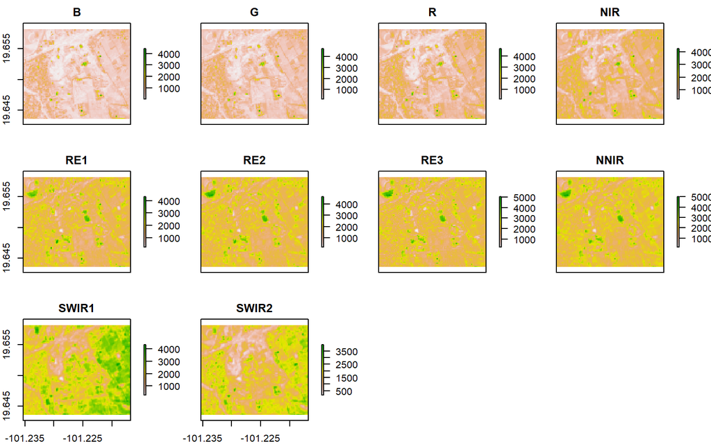

```r
plot(S2)
```

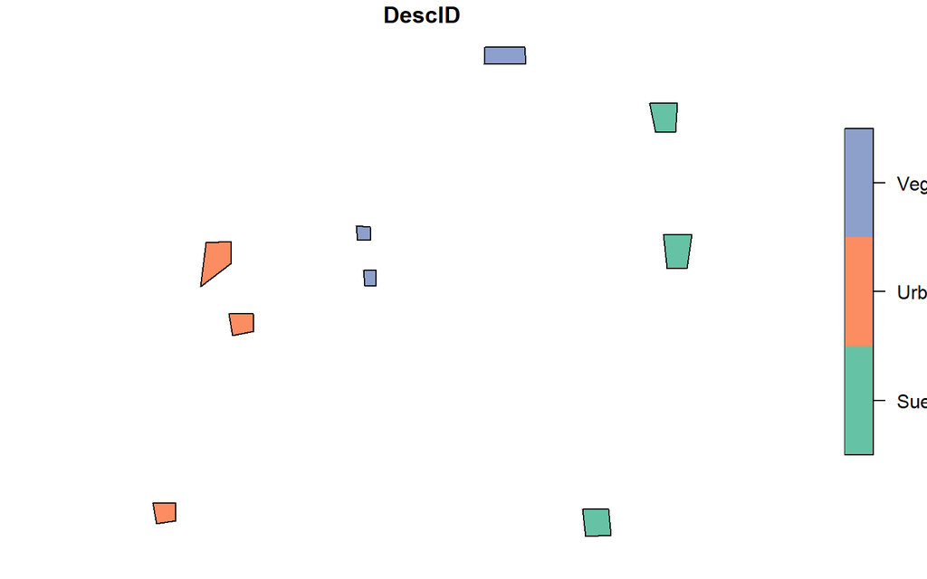

```r
plot(training[3])
```

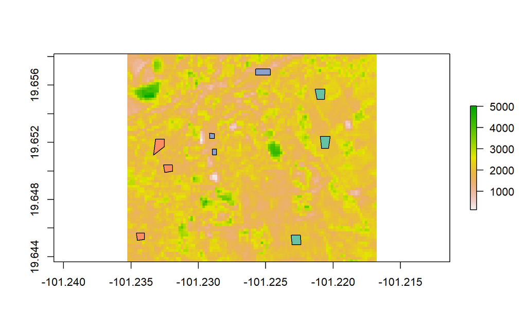

```r
plot(S2[[8]])
plot(training[3], add = T)
```

Extraer los valores de las áreas de entrenamiento ¿Qué es esto?

```r
extracted_info <- raster::extract(S2,training)
head(extracted_info, n = 1)
```

```
## [[1]]
##       B   G   R NIR  RE1  RE2  RE3 NNIR SWIR1 SWIR2
## [1,] 86 236 233 519  965 1393 1475 1530   866   533
## [2,] 67 247 210 459 1167 1399 1448 1495   936   481
## [3,] 94 215 220 482 1154 1529 1606 1682   892   473
## [4,] 76 215 217 540 1400 1363 1449 1616   947   551
```

Convertir la lista de valores a un data.frame

```r
#Se usa la notación :: para llamar funciones dentro de determinados paquetes sin necesidad de cargar el paquete mediante library(paquete)
#Aquí hay que hacer un pequeño truco para poder pasar de list a data.frame
extracted_info<-purrr::map(1:length(extracted_info), function(i) as.data.frame(extracted_info[[i]]))

#Ponerle nombres a cada lista de valores de acuerdo a la ClaseID
names(extracted_info)<-training$DescID
head(extracted_info, n = 1)
```

```
## $Vegetacion
##    B   G   R NIR  RE1  RE2  RE3 NNIR SWIR1 SWIR2
## 1 86 236 233 519  965 1393 1475 1530   866   533
## 2 67 247 210 459 1167 1399 1448 1495   936   481
## 3 94 215 220 482 1154 1529 1606 1682   892   473
## 4 76 215 217 540 1400 1363 1449 1616   947   551
```

```r
#Ya tenemos la información extraida
extracted_info<-dplyr::bind_rows(extracted_info, .id = "id")
head(extracted_info, n = 1)
```

```
##           id  B   G   R NIR RE1  RE2  RE3 NNIR SWIR1 SWIR2
## 1 Vegetacion 86 236 233 519 965 1393 1475 1530   866   533
```

```r
#Cambiar los nombres de las columnas
colnames(extracted_info)<-c("id","B","G","R","NIR","RE1","RE2","RE3","NNIR","SWIR1","SWIR2")
head(extracted_info, n = 1)
```

```
##           id  B   G   R NIR RE1  RE2  RE3 NNIR SWIR1 SWIR2
## 1 Vegetacion 86 236 233 519 965 1393 1475 1530   866   533
```

Veamos como se ven los datos por clase. Vamos a usar `ggplot2` para graficar

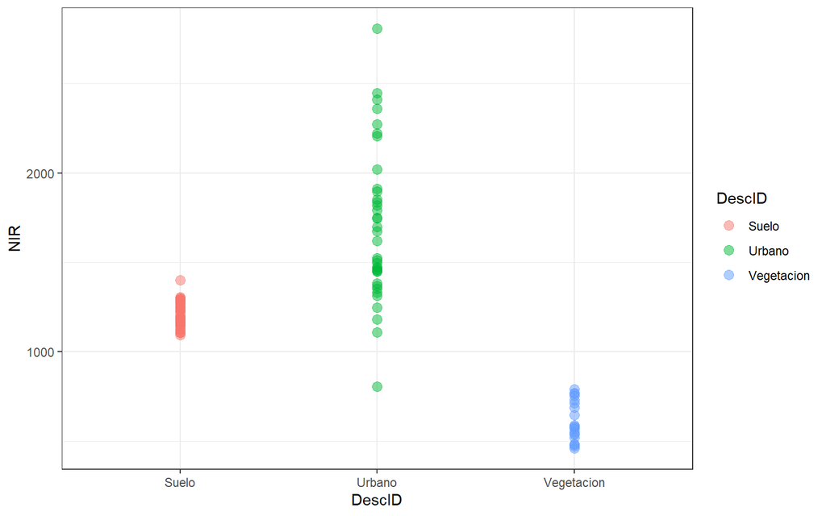

```r
library(ggplot2)
ggplot(extracted_info, aes(x = id,
                           y = NIR,
                           col = id)) +
  geom_point(size = 3, alpha = 0.5) +
  labs(x = "DescID", col = "DescID") +
  theme_bw()
```

Podríamos ver cómo se ven estos valores en cada una de las bandas

```r
library(tidyr)
```

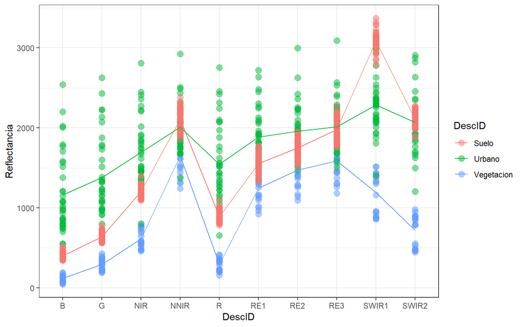

```r
library(ggplot2)
extracted_info %>%
  pivot_longer(cols = -id,
               names_to = "bands",
               values_to = "reflectance") %>%
ggplot( aes(x = bands,
            y = reflectance,
            col = id,
            group = id)) +
  geom_point(size = 3, alpha = 0.5) +
  stat_summary(aes(y = reflectance)
               , fun.y=mean,
               geom="line") +
  labs(x = "DescID",
       y = "Reflectancia",
       col = "DescID") +
  theme_bw()
```

## 1.3 Clasificación máxima verosimilitud (Maximum likelihood)

```r
library(RStoolbox)

ClassMLC<-superClass(img = S2,
           trainData = as(training, 'Spatial'),
           responseCol = "DescID",
           model = "mlc")
```

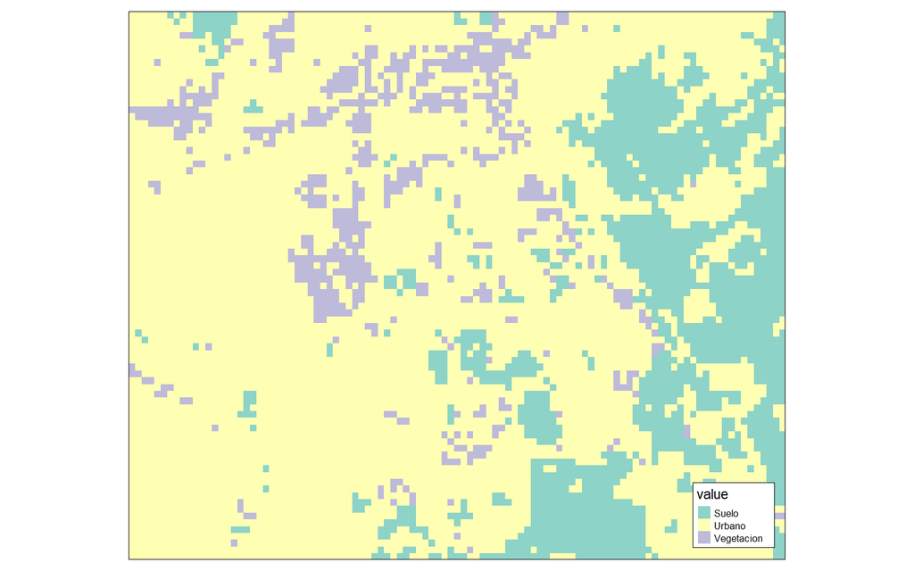

```r
library(tmap)

tm_shape(ClassMLC$map)+
  tm_raster()+
  tm_layout(scale = .8,
            legend.position = c("right","bottom"),
            legend.frame = T,
            legend.bg.color = "white")
```

Si queremos exportar el resultado para abrirlo en QGIS y compararlo con la imagen original

```r
# writeRaster(ClassMLC$map,
#             filename = "Clasificación_MLC.tif",
#             format = "GTiff",
#             dadtaType = "INT2S")
```

## 1.4 Clasificación Árboles de decisión

A partir de la información de entrenamiento se genera un agrupamiento de las categorías.

```r
library(rpart)
library(rpart.plot)

cartmodel <- rpart(as.factor(id)~.,
                   data = extracted_info,
                   method = 'class')

print(cartmodel)
```

```
## n= 102
##
## node), split, n, loss, yval, (yprob)
##       * denotes terminal node
##
## 1) root 102 57 Suelo (0.44117647 0.36274510 0.19607843)
##   2) B< 532.5 66 21 Suelo (0.68181818 0.01515152 0.30303030)
##     4) R>=720 45  0 Suelo (1.00000000 0.00000000 0.00000000) *
##     5) R< 720 21  1 Vegetacion (0.00000000 0.04761905 0.95238095) *
##   3) B>=532.5 36  0 Urbano (0.00000000 1.00000000 0.00000000) *
```

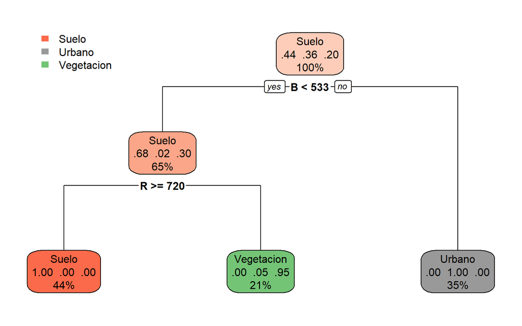

```r
rpart.plot(cartmodel)
```

Ahora utilizamos la información obtenida de los datos de entrenamiento para extrapolarlos a toda la imagen y obtener la clasificación.

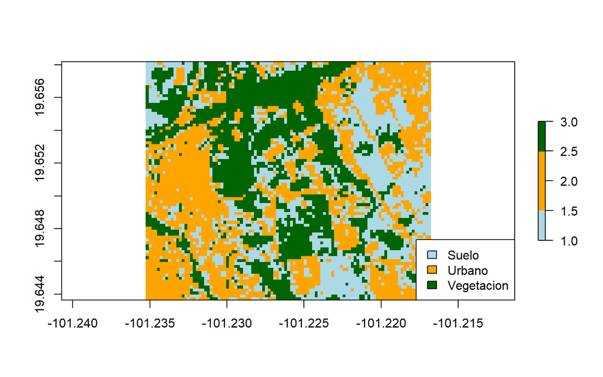

```r
ClassCART <- predict(S2,
                     cartmodel,
                     type = "class")
cols <- c("light blue","orange","dark green")
plot(ClassCART, col = cols)
legend("bottomright",
       legend=as.vector(t(ClassCART@data@attributes[[1]][2])),
       fill=cols, bg="white")
```

### 1.4.1 Clasificación Random Forests

Otra manera de clasificar utilizando random forest. Yo recomiendo esta opción.

Fase de entrenamiento

```r
library(randomForest)
rfmodel <- randomForest(as.factor(id) ~ .,
                   method = "rf",
                   data = extracted_info)

#Ver help(train_model_list) para ver todos los modelos disponibles
#Ver help(randomForest) para ver todos los argumentos disponibles
```

Ya obtuvimos el bosque modelos (ya se ajustaron los árboles) Ver el Out of the Bag Error rate de toda la clasificación

```r
print(rfmodel)
```

```
##
## Call:
##  randomForest(formula = as.factor(id) ~ ., data = extracted_info,      method = "rf")
##                Type of random forest: classification
##                      Number of trees: 500
## No. of variables tried at each split: 3
##
##         OOB estimate of  error rate: 0.98%
## Confusion matrix:
##            Suelo Urbano Vegetacion class.error
## Suelo         45      0          0  0.00000000
## Urbano         0     36          1  0.02702703
## Vegetacion     0      0         20  0.00000000
```

```r
importance(rfmodel, type = 2)
```

```
##       MeanDecreaseGini
## B           13.8636821
## G           12.0863197
## R            7.9227143
## NIR          7.5493199
## RE1          1.3290514
## RE2          0.3323111
## RE3          0.3444938
## NNIR         0.8942046
## SWIR1       12.6556069
## SWIR2        7.2739039
```

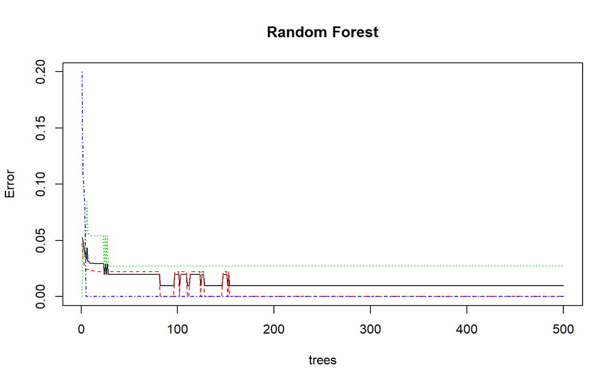

```r
plot(rfmodel, main="Random Forest")
```

### 1.4.2 Evaluación del modelo

```r
#Ubicación para guardar la imagen descargada
location <- "D:/Descargas/Testing.zip"

#Copiar el link para compartir desde google drive
GD_share_URL = "https://drive.google.com/open?id=1fFX9lepmSWEm8wYDv2CEUnPH4LwMy19H"

# Reemplazar "open?" con "us?export=download&"
dwnld_URL <- gsub("open\\?", "uc\\?export=download\\&", GD_share_URL )
dl <- curl::curl_download(dwnld_URL,
                    destfile = location)

#Extraer el archivo descargado
unzip(location,
      exdir = gsub("/Testing.zip","",location))

#Substituir .zip por .shp
location <- gsub(".zip",".shp",location)

testing<-st_read(location)
```

Ya tenemos los datos de validación, así que vamos a correr el modelo para estos datos

```r
extracted_test <- raster::extract(S2,testing)

#Se usa la notación :: para llamar funciones dentro de determinados paquetes sin necesidad de cargar el paquete mediante library(paquete)
#Aquí hay que hacer un pequeño truco para poder pasar de list a data.frame
extracted_test<-purrr::map(1:length(extracted_test), function(i) as.data.frame(extracted_test[[i]]))

#Ponerle nombres a cada lista de valores de acuerdo a la ClaseID
names(extracted_test)<-testing$DescID
head(extracted_test, n = 1)
```

```
## $Vegetacion
##     B   G   R NIR  RE1  RE2  RE3 NNIR SWIR1 SWIR2
## 1 103 297 248 544 1191 1459 1528 1648  1137   667
## 2 156 311 284 535 1146 1336 1331 1384  1029   660
## 3 114 227 235 391  684  784  794  843   832   573
## 4 194 320 351 502  765  910  954 1056   887   637
```

```r
#Ya tenemos la información extraida
extracted_test<-dplyr::bind_rows(extracted_test, .id = "id")
head(extracted_test, n = 1)
```

```
##           id   B   G   R NIR  RE1  RE2  RE3 NNIR SWIR1 SWIR2
## 1 Vegetacion 103 297 248 544 1191 1459 1528 1648  1137   667
```

```r
#Cambiar los nombres de las columnas
colnames(extracted_test)<-c("id","B","G","R","NIR","RE1","RE2","RE3","NNIR","SWIR1","SWIR2")
head(extracted_test, n = 1)
```

```
##           id   B   G   R NIR  RE1  RE2  RE3 NNIR SWIR1 SWIR2
## 1 Vegetacion 103 297 248 544 1191 1459 1528 1648  1137   667
```

Ya tenemos los datos extraidos del raster para la verificación, así que procedemos a correr el modelo para esos datos. Y vemos su matriz de error

```r
ClassRF <- predict(rfmodel, extracted_test)
confusion_matrix<-table(ClassRF, extracted_test$id)
confusion_matrix
```

```
##
## ClassRF      Suelo Urbano Vegetacion
##   Suelo         19      0          0
##   Urbano        10     20          0
##   Vegetacion     0      0         11
```

### 1.4.3 Clasificación de la imagen

Aquí ya obtenemos la imagen clasificada

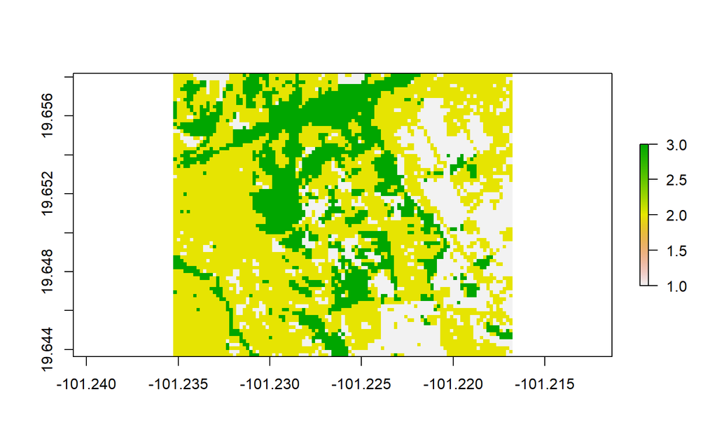

```r
ClassRF_raster <- predict(S2,
                     rfmodel)
plot(ClassRF_raster)
```

```r
ClassRF_raster@data@attributes[[1]]
```

```
##   ID      value
## 1  1      Suelo
## 2  2     Urbano
## 3  3 Vegetacion
```

### 1.4.4 Calculo de precisión total y kappa

Ahora ya que tenemos todo deberíamos conocer cuál es la precisión del método

```r
#Obtenemos el número de observaciones en los datos de validación
n_test <- nrow(extracted_test)
#Obtenemos el número de clases en los datos de validación
n_clases <- length(levels(extracted_test$id))

overall_accuracy <- sum(diag(confusion_matrix)) / n_test
overall_accuracy
```

```
## [1] 0.8333333
```

```r
#Realizar sumas por renglones en la matriz de error
#Obtener la precisión del usuario
users_accuracy <- sapply(1:nrow(confusion_matrix), function(i){
  confusion_matrix[i,i] / sum( confusion_matrix[i,])
})
names(users_accuracy) <- colnames(confusion_matrix)
users_accuracy
```

```
##      Suelo     Urbano Vegetacion
##  1.0000000  0.6666667  1.0000000
```

```r
#Obtener la precisión del producto
producers_accuracy <- sapply(1:nrow(confusion_matrix), function(i){
  confusion_matrix[i,i] / sum( confusion_matrix[,i])
})
names(producers_accuracy) <- row.names(confusion_matrix)
producers_accuracy
```

```
##      Suelo     Urbano Vegetacion
##  0.6551724  1.0000000  1.0000000
```

Una forma que quizás sea más sencilla

```r
#Obtener kappa y la precisión total
caret::confusionMatrix(ClassRF, as.factor(extracted_test$id))
```

```
## Confusion Matrix and Statistics
##
##             Reference
## Prediction   Suelo Urbano Vegetacion
##   Suelo         19      0          0
##   Urbano        10     20          0
##   Vegetacion     0      0         11
##
## Overall Statistics
##
##                Accuracy : 0.8333
##                  95% CI : (0.7148, 0.9171)
##     No Information Rate : 0.4833
##     P-Value [Acc > NIR] : 2.029e-08
##
##                   Kappa : 0.7423
##
##  Mcnemar's Test P-Value : NA
##
## Statistics by Class:
##
##                      Class: Suelo Class: Urbano Class: Vegetacion
## Sensitivity                0.6552        1.0000            1.0000
## Specificity                1.0000        0.7500            1.0000
## Pos Pred Value             1.0000        0.6667            1.0000
## Neg Pred Value             0.7561        1.0000            1.0000
## Prevalence                 0.4833        0.3333            0.1833
## Detection Rate             0.3167        0.3333            0.1833
## Detection Prevalence       0.3167        0.5000            0.1833
## Balanced Accuracy          0.8276        0.8750            1.0000
```

### 1.4.5 Estadísticas básicas de resultado

Se pueden calcular estadísticas de las imágenes clasificadas.

```r
freq(ClassRF_raster)
```

```
##      value count
## [1,]     1  1845
## [2,]     2  4529
## [3,]     3  1969
```

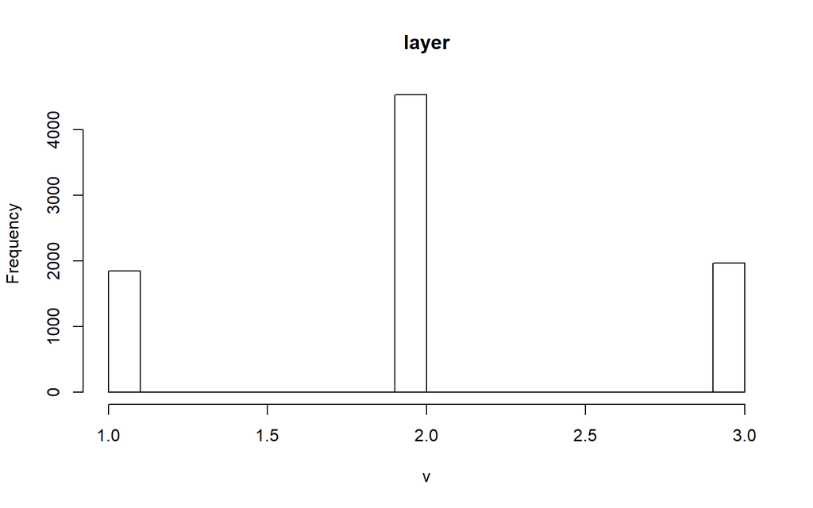

```r
hist(ClassRF_raster)
```

Si quisieramos conocer el área ocupada por una categoría

```r
#Area en km2
ar<-area(ClassRF_raster)

#Area promedio por pixel en km2
area_pix<-mean(ar@data@values)
area_pix
```

```
## [1] 0.0003743235
```

```r
#tamaño lineal por lado del pixel
sqrt(mean(ar@data@values))
```

```
## [1] 0.01934744
```

```r
resul_areas<-freq(ClassRF_raster)
resul_areas
```

```
##      value count
## [1,]     1  1845
## [2,]     2  4529
## [3,]     3  1969
```

```r
str(resul_areas)
```

```
##  num [1:3, 1:2] 1 2 3 1845 4529 ...
##  - attr(*, "dimnames")=List of 2
##   ..$ : NULL
##   ..$ : chr [1:2] "value" "count"
```

```r
#Convertir la lista a data.frame
freq_table<-data.frame(matrix(unlist(resul_areas),
                  nrow=3,
                  byrow=F))
colnames(freq_table)<-c("id","num_pix")
freq_table$area_ha <- freq_table$num_pix * (area_pix * 100)
freq_table
```

```
##   id num_pix   area_ha
## 1  1    1845  69.06269
## 2  2    4529 169.53113
## 3  3    1969  73.70430
```